# GET00203 - Estatística Computacional 1

Aula 06 - Distribuições Amostrais - Parte III

[Rafael Erbisti](https://sites.google.com/site/rerbisti)

#### Exemplo 1

Uma variável aleatória $X$ tem distribuição Cauchy com parâmetro $\theta$ e $\gamma^2 > 0$ se sua função densidade de probabilidade é dada por
$$f(x) = \frac{1}{\pi \gamma} \left[ 1 + \left( \frac{x - \theta}{\gamma}
\right)^2 \right]^{-1}, \quad x \in \mathbb{R}.$$

1. Sem utilizar funções prontas do R, crie uma função que, dados os parâmetros da distribuição, retorne o valor da função de densidade de probabilidade de $X$. Fixando $\theta = 3$ e $\gamma^2 = 4$.
2. Faça um gráfico desta função de densidade de probabilidade, com $x$ no intervalo $[-10, 20]$.
3. Faça um gráfico da função de distribuição acumulada de $X$.
4. Calcule $P(1 < X \leq 3)$.

##### Solução

```r
# 1)
dens.cauchy = function(x, theta = 3, gamma = 2) {
  return(1 / (pi * gamma * (1 + ((x - theta) / gamma)^2)))
}
```

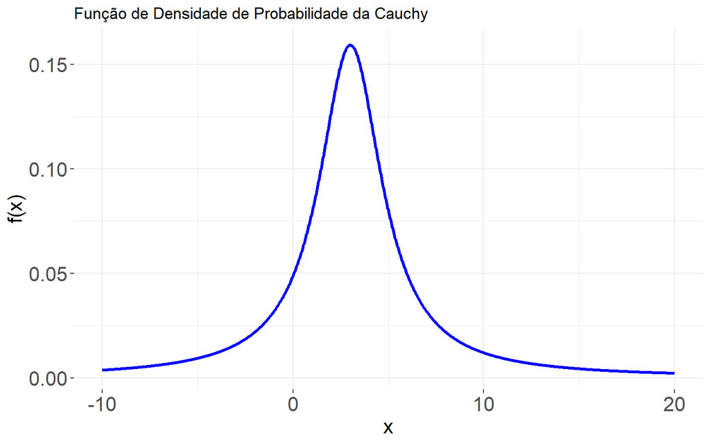

```r
# 2)
# Criar valores de x no intervalo [-10, 20]
x_values <- seq(-10, 20, length.out = 1000)

# Calcular os valores da densidade
pdf_valores <- dens.cauchy(x_values, theta = 3, gamma = 2)

# Criar um data frame para o ggplot2
df <- data.frame(x = x_values, density = pdf_valores)

# Gerar o gráfico usando ggplot2
ggplot(df, aes(x = x, y = density)) +
  geom_line(color = "blue", size = 1.2) +
  labs(title = "Função de Densidade de Probabilidade da Cauchy",
       x = "x", y = "f(x)") +
  theme_bw() +
  theme(axis.text.x = element_text(size = 16),
        axis.title.x = element_text(size = 16),
        axis.text.y = element_text(size = 16),
        axis.title.y = element_text(size = 16),
        panel.border = element_blank())
```

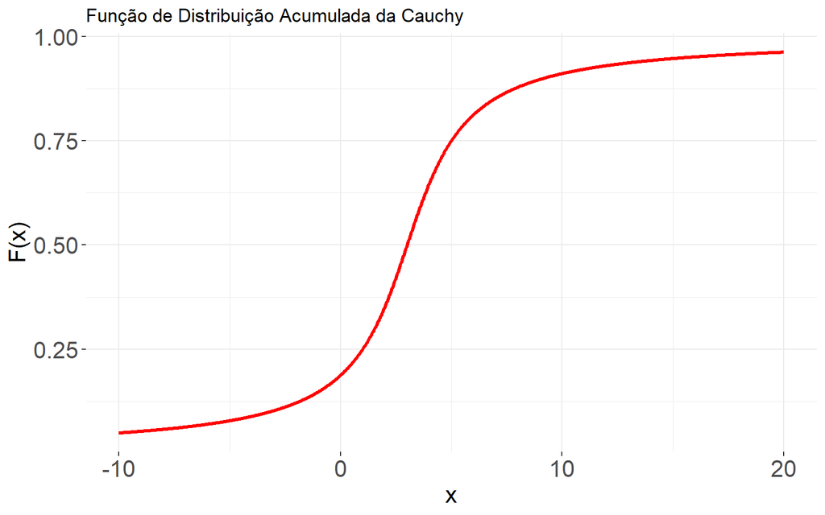

```r
# 3)
# Criar valores de x no intervalo [-10, 20]
x_values <- seq(-10, 20, length.out = 1000)

# Calcular os valores da FDA usando pcauchy
fda_values <- pcauchy(x_values, location = 3, scale = 2)

# Criar um data frame para o ggplot2
df <- data.frame(x = x_values, fda = fda_values)

# Gerar o gráfico da FDA usando ggplot2
ggplot(df, aes(x = x, y = fda)) +
  geom_line(color = "red", size = 1.2) +
  labs(title = "Função de Distribuição Acumulada da Cauchy",
       x = "x", y = "F(x)") +
  theme_bw() +
  theme(axis.text.x = element_text(size = 16),
        axis.title.x = element_text(size = 16),
        axis.text.y = element_text(size = 16),
        axis.title.y = element_text(size = 16),
        panel.border = element_blank())
```

```r
# 4)
# Calcular P(1 < X <= 3) usando pcauchy
p_value <- pcauchy(3, location = 3, scale = 2) - pcauchy(1, location = 3, scale = 2)
p_value
```

```
[1] 0.25
```

#### Exemplo 2

Seja $X_1, \dots, X_n$ uma amostra aleatória simples de uma distribuição $N(10, 32)$. Sabe-se que
$$T = \dfrac{\left(\dfrac{\bar{X} - \mu}{\sigma /
\sqrt{n}}\right)^2}{S^2/\sigma^2} \sim F(1, n-1),$$

com $S^2 = \frac{\sum_{i=1}^{n} (X_i - \bar{X})^2}{n - 1}$.

1. Mostre graficamente que este resultado é verdadeiro, gerando 1200 amostras de tamanho $n = 50$ da distribuição normal em questão (fixe a semente 111 na geração).
2. Faça um gráfico qqplot que permita concluir o mesmo sobre esta aproximação.

*Observação*: $F(\nu_1, \nu_2)$ representa a distribuição F de Snedecor com graus de liberdade $\nu_1$ e $\nu_2$.

##### Solução

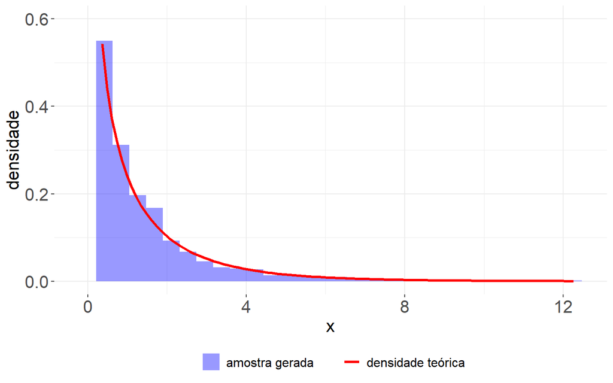

```r
# 1)
# Fixando a semente
set.seed(111)

# Definindo os parâmetros
n = 50
mu = 10
sigma2 = 32
num_samples = 1200

# Gerando 1200 amostras de tamanho 50
samples <- replicate(num_samples, rnorm(n, mean = mu, sd = sqrt(sigma2)))

# Calculando a média amostral e o desvio padrão amostral
sample_means <- colMeans(samples)
sample_vars <- apply(samples, 2, var)

# Calculando a estatística T
T_values <- (((sample_means - mu) / (sqrt(sigma2 / n)))^2)/(sample_vars/sigma2)

# Plotando o histograma dos valores de T
ggplot(data = tibble(x = T_values), mapping = aes(x = x)) +
  geom_histogram(aes(y = ..density.., fill = "amostra gerada"), alpha = 0.4) +
  stat_function(fun = stats::df, args = list(df1 = 1, df2 = n-1),
                aes(color = "densidade teórica"), linewidth=1.2) +
  labs(y = "densidade", x = "x", fill = "", color = "") +
  ylim(0, 0.6) +
  scale_fill_manual(values = c("amostra gerada" = "blue")) +
  scale_color_manual(values = c("densidade teórica" = "red")) +
  theme_bw() +
  theme(axis.text.x = element_text(size = 16),
        axis.title.x = element_text(size = 16),
        axis.text.y = element_text(size = 16),
        axis.title.y = element_text(size = 16),
        panel.border = element_blank(),
        legend.position = "bottom",
        legend.text = element_text(size = 12))
```

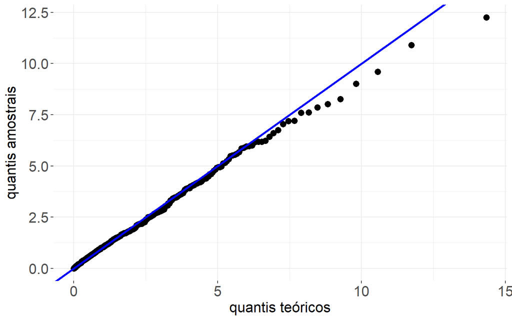

```r
# 2)
ggplot(data = tibble(x = T_values), aes(sample = x)) +
  stat_qq(distribution = qf, dparams = list(df1 = 1, df2 = n-1), size = 3) +
  geom_abline(intercept = 0, col = "blue", size = 1.2) +
  labs(x = "quantis teóricos",
       y = "quantis amostrais") +
  theme_bw() +
  theme(axis.text.x = element_text(size = 16),
        axis.title.x = element_text(size = 16),
        axis.text.y = element_text(size = 16),
        axis.title.y = element_text(size = 16),
        panel.border = element_blank())
```

#### Exemplo 3

Suponha que $X$ tenha a seguinte função de probabilidade:

| x | 1 | 3 | 4 | 5 |
| --- | --- | --- | --- | --- |
| P(X = x) | 0.15 | 0.35 | 0.10 | 0.40 |

Faça o que se pede:

1. Gere uma amostra de tamanho 300 de $X$.
2. Faça o gráfico da função de probabilidade de $X$.
3. Seja $Y = X^2 + 2W$, sendo $W \sim \text{Bin}(3, 0.4)$. Gere uma amostra de $Y$ de tamanho 300. Construa a tabela de distribuição de frequências de $Y$.

##### Solução

```r
# 1)
# Definir os valores de X e suas probabilidades
valores_X <- c(1, 3, 4, 5)
probs_X <- c(0.15, 0.35, 0.10, 0.40)

# Gerar uma amostra de tamanho 300 de X
amostra_X <- sample(valores_X, size = 300, replace = TRUE, prob = probs_X)
amostra_X
```

```
 [1] 3 1 1 5 4 5 5 5 4 3 1 1 5 3 5 5 1 5 5 1 5 3 3 5 5 5 5 5 3 4 5 1 5 3 5 5 5 1
[39] 3 1 3 5 5 5 3 5 5 1 5 5 5 3 4 3 1 1 5 3 3 4 1 5 5 1 3 5 1 3 3 1 5 5 5 5 5
 [ reached getOption("max.print") -- omitted 225 entries ]
```

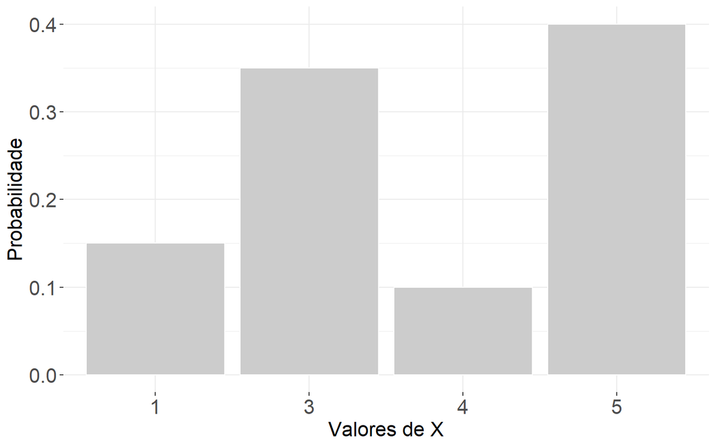

```r
# 2)
# Criar um dataframe com a função de probabilidade
df_prob <- tibble(
  x = valores_X,
  prob = probs_X)

# Fazer o gráfico da função de probabilidade de X
ggplot(df_prob, aes(x = factor(x), y = prob)) +
  geom_bar(stat = "identity", fill = "gray80", color = "white") +
  labs(x = "Valores de X", y = "Probabilidade") +
  theme_bw() +
  theme(axis.text.x = element_text(size = 16),
        axis.title.x = element_text(size = 16),
        axis.text.y = element_text(size = 16),
        axis.title.y = element_text(size = 16),
        panel.border = element_blank())
```

```r
# 3)
# Tamanho da amostra
n <- 300

# Definir a distribuição de X
valores_X <- c(1, 3, 4, 5)
probs_X <- c(0.15, 0.35, 0.10, 0.40)

# Gerar amostras de X com a distribuição dada
X <- sample(valores_X, size = n, replace = TRUE, prob = probs_X)

# Gerar amostras de W (Binomial(3, 0.4))
W <- rbinom(n, size = 3, prob = 0.4)

# Calcular Y = X^2 + 2W
Y <- X^2 + 2 * W

# Construir a tabela de distribuição de frequências de Y
tabela_frequencias <- as.data.frame(table(Y))

# Calcular porcentagens e porcentagens acumuladas
tabela_frequencias <- tabela_frequencias |>
  mutate(Porcentagem = round(Freq / n * 100,1),
         Porcentagem_Acumulada = cumsum(Porcentagem))

# Organizar a tabela por Y
tabela_frequencias <- tabela_frequencias |>
  arrange(Y)

# Mostrar a tabela de distribuição de frequências com porcentagens e acumuladas
print(tabela_frequencias)
```

```
    Y Freq Porcentagem Porcentagem_Acumulada
1   1   10         3.3                   3.3
2   3   21         7.0                  10.3
3   5    9         3.0                  13.3
4   7    6         2.0                  15.3
5   9   29         9.7                  25.0
6  11   49        16.3                  41.3
7  13   30        10.0                  51.3
8  15    7         2.3                  53.6
9  16    4         1.3                  54.9
10 18   12         4.0                  58.9
11 20    7         2.3                  61.2
12 25   26         8.7                  69.9
13 27   46        15.3                  85.2
14 29   34        11.3                  96.5
15 31   10         3.3                  99.8
```

> **Desafio:** Seja $Y \sim N(100, 4)$ e $X \sim N(40, 9)$. Definimos $U$ como
> $$U = \frac{4S_X^2}{9S_Y^2}$$
> onde $S_X^2$ é a variância amostral de $X$ e $S_Y^2$ é a variância amostral de $Y$. Agora, siga os seguintes passos: 1. Gere uma amostra de $U$ de tamanho 1000, considerando $n_X = 100$ e $n_Y = 300$. 2. Compare o histograma da amostra gerada com a função de densidade obtida através da função $\text{df}$ da distribuição $F$. 3. Verifique empiricamente se $U \sim F(n_X, n_Y)$, onde $n_X$ e $n_Y$ são os tamanhos amostrais de $X$ e $Y$, respectivamente.